# Final Exam – PHC6099 Programming Basics for Biostatistics FALL 2024

### Total points: 100 (25% of final grade).

### Due: 11:59 pm, Dec 8th, 2024

## Name: Joseph Dickerson

```python
import pandas as pd
import numpy as np
import matplotlib.pyplot as plt
import seaborn as sns
pd.options.mode.chained_assignment = None
```

### Instructions (5 pts)

Make sure you read the following. Fail to follow these instructions may result in points deduction .

- You only need to submit a HTML file (instead of the ipynb file) electronically. For all exam questions, please print out your answers so that we can see them in the HTML file. Your procedures (Python code) should be displayed as well (usually this is automatic).
- If you generate a figure, please write appropriate figure titles, labels, legends, if necessary.
- If your code is not intuitive, please write comments to make the code readable.
- There is no restriction on which Python functions/packages to use, as long as you can answer the questions.
- You are not allowed to discuss with any other people. Please email the instructor if you have any clarification questions.
- Don’t forget to put your name on the top of the html page (e.g., Names: ). In addition, rename the html file in the format “2024_PHC6099_finalExam_YourName.html”, and replace “YourName” with your name.
- Submission due is 11:59 pm, Dec 8th, 2024 and there is not any grace period for the final exam. If your final exam is not recieved by the due time, it won’t be graded. Please consider to submit earlier just in case there are any IT technical issues. Or you can at least submit your draft and update your answers later. We will only grade the latest submission before the deadline.

## Data description.

#### Reference

- Fanaee-T, Hadi, and Gama, Joao, "Event labeling combining ensemble detectors and background knowledge", Progress in Artificial Intelligence (2013): pp. 1-15, Springer Berlin Heidelberg, doi:10.1007/s13748-013-0040-3.
- https://archive.ics.uci.edu/ml/datasets/Bike+Sharing+Dataset

#### Background

Bike sharing systems are new generation of traditional bike rentals where whole process from membership, rental and return back has become automatic. Through these systems, user is able to easily rent a bike from a particular position and return back at another position. Currently, there are about over 500 bike-sharing programs around the world which is composed of over 500 thousands bicycles. Today, there exists great interest in these systems due to their important roles in traffic, environmental and health issues.

Apart from interesting real world applications of bike sharing systems, the characteristics of data being generated by these systems make them attractive for the research. Opposed to other transport services such as bus or subway, the duration of travel, departure and arrival position is explicitly recorded in these systems. This feature turns bike sharing system into a virtual sensor network that can be used for sensing mobility in the city. Hence, it is expected that most of important events in the city could be detected via monitoring these data.

[figure not shown]

#### Dataset sources

Bike-sharing rental process is highly correlated to the environmental and seasonal settings. For instance, weather situation, precipitation, day of week, season, hour of the day, etc. can affect the rental behaviors. The core data set is related to the two-year historical log corresponding to years 2011 and 2012 from Capital Bikeshare system, Washington D.C., USA, which is publicly available in https://capitalbikeshare.com/system-data. We aggregated the data on a daily basis and then extracted and added the corresponding weather and seasonal information. Weather information are extracted from https://www.freemeteo.com.

#### Files

The prepared data file is available at https://Caleb-Huo.github.io/teaching/data/BikeSharing/day.csv. **Your analysis should base on this data. Unless specified, you are supposed to use all observations in this dataset.**

#### Dataset characteristics

- instant: record index
- dteday : date
- season : season (1:spring, 2:summer, 3:fall, 4:winter)
- yr : year (0: 2011, 1:2012)
- mnth : month ( 1 to 12)
- holiday : weather day is holiday or not (extracted from http://dchr.dc.gov/page/holiday-schedule)
- weekday : day of the week
- workingday : if day is neither weekend nor holiday is 1, otherwise is 0.
- weathersit :
  - 1: Clear, Few clouds, Partly cloudy, Partly cloudy
  - 2: Mist + Cloudy, Mist + Broken clouds, Mist + Few clouds, Mist
  - 3: Light Snow, Light Rain + Thunderstorm + Scattered clouds, Light Rain + Scattered clouds
- temp : Normalized temperature in Celsius. The values are divided to 41 (max)
- hum: Normalized humidity. The values are divided to 100 (max)
- windspeed: Normalized wind speed. The values are divided to 67 (max)
- casual: count of casual users
- registered: count of registered users
- cnt: count of total rental bikes including both casual and registered

## Analysis

### Question 0. (5 pts)

You may want to read in the data here. Print the first 10 lines of the data.

```python
data = pd.read_csv("https://Caleb-Huo.github.io/teaching/data/BikeSharing/day.csv")
data[0:10]
```

|  | instant | dteday | season | yr | mnth | holiday | weekday | workingday | weathersit | temp | hum | windspeed | casual | registered | cnt |
| --- | --- | --- | --- | --- | --- | --- | --- | --- | --- | --- | --- | --- | --- | --- | --- |
| 0 | 1 | 1/1/11 | 1 | 0 | 1 | 0 | 6 | 0 | 2 | 0.344167 | 0.805833 | 0.160446 | 331 | 654 | 985 |
| 1 | 2 | 1/2/11 | 1 | 0 | 1 | 0 | 0 | 0 | 2 | 0.363478 | 0.696087 | 0.248539 | 131 | 670 | 801 |
| 2 | 3 | 1/3/11 | 1 | 0 | 1 | 0 | 1 | 1 | 1 | 0.196364 | 0.437273 | 0.248309 | 120 | 1229 | 1349 |
| 3 | 4 | 1/4/11 | 1 | 0 | 1 | 0 | 2 | 1 | 1 | 0.200000 | 0.590435 | 0.160296 | 108 | 1454 | 1562 |
| 4 | 5 | 1/5/11 | 1 | 0 | 1 | 0 | 3 | 1 | 1 | 0.226957 | 0.436957 | 0.186900 | 82 | 1518 | 1600 |
| 5 | 6 | 1/6/11 | 1 | 0 | 1 | 0 | 4 | 1 | 1 | 0.204348 | 0.518261 | 0.089565 | 88 | 1518 | 1606 |
| 6 | 7 | 1/7/11 | 1 | 0 | 1 | 0 | 5 | 1 | 2 | 0.196522 | 0.498696 | 0.168726 | 148 | 1362 | 1510 |
| 7 | 8 | 1/8/11 | 1 | 0 | 1 | 0 | 6 | 0 | 2 | 0.165000 | 0.535833 | 0.266804 | 68 | 891 | 959 |
| 8 | 9 | 1/9/11 | 1 | 0 | 1 | 0 | 0 | 0 | 1 | 0.138333 | 0.434167 | 0.361950 | 54 | 768 | 822 |
| 9 | 10 | 1/10/11 | 1 | 0 | 1 | 0 | 1 | 1 | 1 | 0.150833 | 0.482917 | 0.223267 | 41 | 1280 | 1321 |

### Question 1. (9 pts)

How many days are with hum >= 0.5 and windspeed >= 0.3? Among them, what is the percentage of severe whether situation (i.e., weathersit == 3)? For the percentage, only keep the integer part (e.g., 10.35% --> 10%).

```python
day_count = data[(data["hum"] >= 0.5) & (data["windspeed"] >= 0.3)]

weather_count = len(day_count[day_count["weathersit"] == 3])

pct = round((weather_count / len(day_count) * 100), 0)

print(f"{len(day_count)} days with humidity >= 0.5 and windspeed >= 0.3. {int(pct)}% of these days have severe weather situation.")
```

```
41 days with humidity >= 0.5 and windspeed >= 0.3. 15% of these days have severe weather situation.
```

### Question 2. (9 pts)

Write a function, the input is a vector. The output is a **dictionary** of max, min, mean, median, range (i.e., max - min),interquartile range (IQR) of the vector. Then apply this function to the temp attribute of the entire data.

```python
def temp_dict(temp):
    temp = np.array(temp)

    max_value = float(np.max(temp))
    min_value = float(np.min(temp))
    mean_value = float(np.mean(temp))
    median_value = float(np.median(temp))
    range_value = max_value - min_value

    x = np.percentile(temp, 25)
    y = np.percentile(temp, 75)
    iqr = float(y - x)

    dictionary = {
        "max": max_value,
        "min": min_value,
        "mean": mean_value,
        "median": median_value,
        "range": range_value,
        "IQR": iqr
    }

    return dictionary

temp_dict(data["temp"])
```

```
{'max': 0.861667,
 'min': 0.0591304,
 'mean': 0.495384788508892,
 'median': 0.498333,
 'range': 0.8025365999999999,
 'IQR': 0.3183330000000001}
```

### Question 3. (9 pts)

Prepare a summary tables by season in year 2011. The result should look like the table below. For age (continuous variable), calculate its mean and standard devition for each group, and keep 2 digits after decimal. Note that you also need to use the exact row index or column index in the final result.

| Type | spring | summer | fall | winter |
| --- | --- | --- | --- | --- |
| `N` | count | count | count | count |
| `temp` | mean (SD) | mean (SD) | mean (SD) | mean (SD) |
| `hum` | mean (SD) | mean (SD) | mean (SD) | mean (SD) |
| `windspeed` | mean (SD) | mean (SD) | mean (SD) | mean (SD) |

```python
data_2011 = data[data["yr"] == 0]
cols = ["cnt", "temp", "hum", "windspeed"]
summary = pd.DataFrame(columns=["spring", "summer", "fall", "winter"], index=["N", "temp", "hum", "windspeed"])

for x in cols:
    for season in [1, 2, 3, 4]:
        season_data = data_2011[data_2011["season"] == season]

        if x == "cnt":
            if not season_data.empty:
                summary.loc["N", ["spring", "summer", "fall", "winter"][season-1]] = season_data[x].sum()
        else:
            if not season_data.empty:
                mean_val = season_data[x].mean()
                std_val = season_data[x].std()
                summary.loc[x, ["spring", "summer", "fall", "winter"][season-1]] = f"{mean_val:.2f} ({std_val:.2f})"

print(summary)
```

```
                spring       summer         fall       winter
N               150000       347316       419650       326137
temp       0.27 (0.10)  0.53 (0.14)  0.70 (0.07)  0.43 (0.11)
hum        0.58 (0.16)  0.66 (0.15)  0.64 (0.13)  0.69 (0.13)
windspeed  0.21 (0.08)  0.21 (0.07)  0.18 (0.06)  0.17 (0.08)
```

## Question 4. (9 pts)

For the data in 2011, sort the data by temp (assending) and windspeed (decending). What is the weather condition (i.e., weathersit) for the first 30 days in the sorted data? Summarize the frequency of each weather condition (you can just use 1,2, or 3 to indicate the weather condition).

```python
data_2011 = data[data["yr"] == 0]

data_2011_sort = data_2011.sort_values(by = ["temp", "windspeed"], ascending = [True, False])

data_30 = data_2011_sort.head(30)

data_30["weathersit"].value_counts()
```

```
weathersit
1    20
2    10
Name: count, dtype: int64
```

## Question 5. (9 pts)

Draw histograms for count of total rental bikes (cnt), and stratified by seasons using data in 2011. The height of the histogram should represent the density instead of the frequency. Also draw the density function (in red color) on top of the histogram.

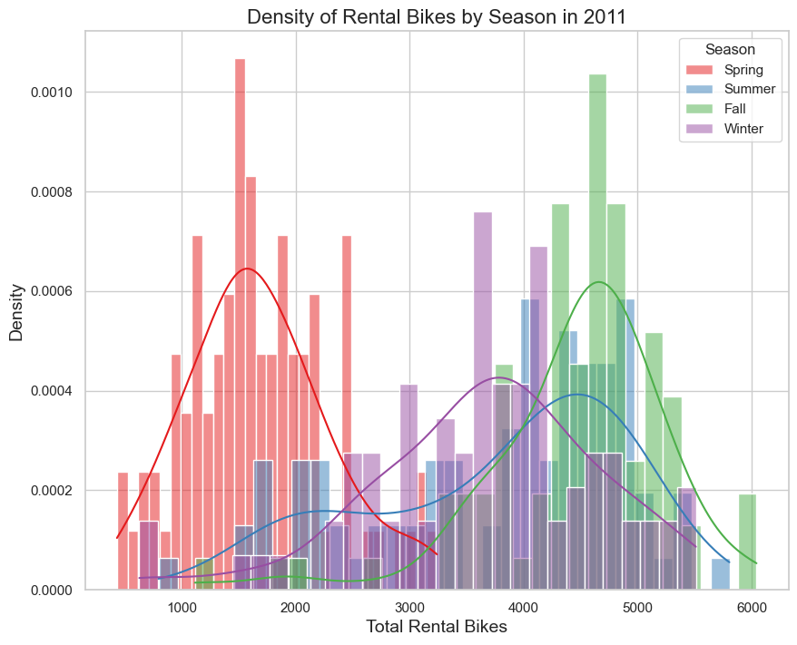

```python
data_2011 = data[data["yr"] == 0]

season_names = {1: "Spring", 2: "Summer", 3: "Fall", 4: "Winter"}

plt.figure(figsize=(10, 8))

bins = 30

for season in [1, 2, 3, 4]:

    season_data = data_2011[data_2011["season"] == season]

    sns.histplot(season_data["cnt"], kde=True, stat="density", bins=bins, label=season_names[season],
                 color=sns.color_palette("Set1")[season-1])

plt.title("Density of Rental Bikes by Season in 2011", fontsize=16)
plt.xlabel("Total Rental Bikes", fontsize=14)
plt.ylabel("Density", fontsize=14)
plt.legend(title="Season", loc="upper right")

plt.show()
```

### Question 6. (9 pts)

We want to do some string manipulations for the attribute dteday. For each of the 731 instances, first, only keep months and days. For example, 1/1/11 should become 1/1, and 10/17/12 should become 10/17. Then change 0,1,2,3,4 to A; change 5,6,7,8,9 to B; change / to -. For example, 1/1 should become “A-A”; 10/17 should become “AA-AB”. Print the first 10 instances after such conversion. How many instances have more letter A than letter B? (i.e., #A > #B)

```python
data["month_day"] = data["dteday"].apply(lambda x: x.split("/")[0] + "/" + x.split("/")[1])

def transform(date_str):
    date_str = date_str.replace("/", "-")

    date_str = "".join(["A" if ch in "01234" else "B" if ch in "56789" else ch for ch in date_str])

    return date_str

data["transformed_date"] = data["month_day"].apply(transform)

print(data["transformed_date"].head(10))

def countAmorethanB(date_str):
    countA = date_str.count("A")
    countB = date_str.count("B")
    return countA > countB

count_A_greater_B = data["transformed_date"].apply(countAmorethanB).sum()

print(f"Number of instances with more A than B: {count_A_greater_B}")
```

```
0     A-A
1     A-A
2     A-A
3     A-A
4     A-B
5     A-B
6     A-B
7     A-B
8     A-B
9    A-AA
Name: transformed_date, dtype: object
Number of instances with more A than B: 501
```

## Question 7. (9 pts)

Based on the date in year 2011, create a new binary variable “temp_b” based on the temp. If temp > median(temp), temp_b is hot; if temp <= median(temp), temp_b is cold. Draw scattered plot of casual (x-axis) vs registered (y-axis), the color of each dot represents the temp_b. For each group, draw a linear regression line fitting the all data point in the same group.

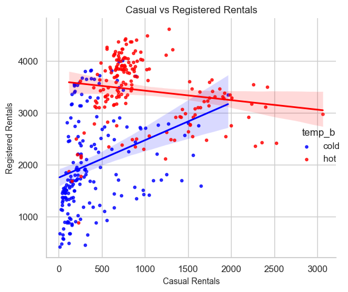

```python
data_2011 = data[data["yr"] == 0]
temp_median = data_2011["temp"].median()
data_2011.loc[:, "temp_b"] = data_2011["temp"].apply(lambda x: "hot" if x > temp_median else "cold")

sns.set(style = "whitegrid")

sns.lmplot(x = "casual", y = "registered", hue = "temp_b", data = data_2011, palette = {"cold": "blue", "hot": "red"},
           logistic = False, markers = "o", scatter_kws = {"s": 10}, line_kws = {"linewidth": 2})

plt.title("Casual vs Registered Rentals", fontsize = 12)
plt.xlabel("Casual Rentals", fontsize = 10)
plt.ylabel("Registered Rentals", fontsize = 10)
plt.tight_layout()

plt.show()
```

## Question 8. (9 pts)

We want to look at the temperature and humidity change over time in May 2012. Plot the temperature and humidity trajectory over time in the same figure with two different colors. The x-axis should be the date. Mark the Pearson correlation (keep 2 digits after decimal) between temperature and humidity over this time period in the figure title.

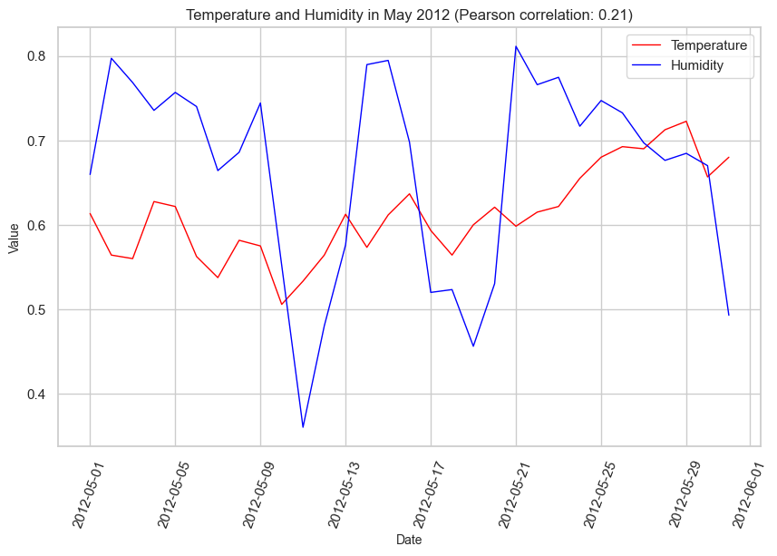

```python
data_2012 = data[(data["yr"] == 1) & (data["mnth"] == 5)]

data_2012['dteday'] = pd.to_datetime(data_2012['dteday'])

correlation = data_2012['temp'].corr(data_2012['hum'])

plt.figure(figsize=(10, 6))

plt.plot(data_2012['dteday'], data_2012['temp'], label='Temperature', color='red', linewidth=1)
plt.plot(data_2012['dteday'], data_2012['hum'], label='Humidity', color='blue', linewidth=1)

plt.title(f"Temperature and Humidity in May 2012 (Pearson correlation: {correlation:.2f})", fontsize=12)
plt.xlabel("Date", fontsize=10)
plt.ylabel("Value", fontsize=10)

plt.xticks(rotation=70)

plt.legend()

plt.show()
```

### Question 9. (9 pts)

Based on the data in year 2011, generate a boxplot to illustrate the distribution of bike rental counts across different weather situations, categorized by user type: casual, registered, and total count. It should be organized into three distinct panels, each corresponding to one of the user categories. Within each panel, box plots should display the count of bike rentals for three weather situations (denoted by different colors), which are coded numerically as 1, 2, and 3. The box plots should provide a visual representation of the central tendency and variability of rentals for each weather situation and user type.

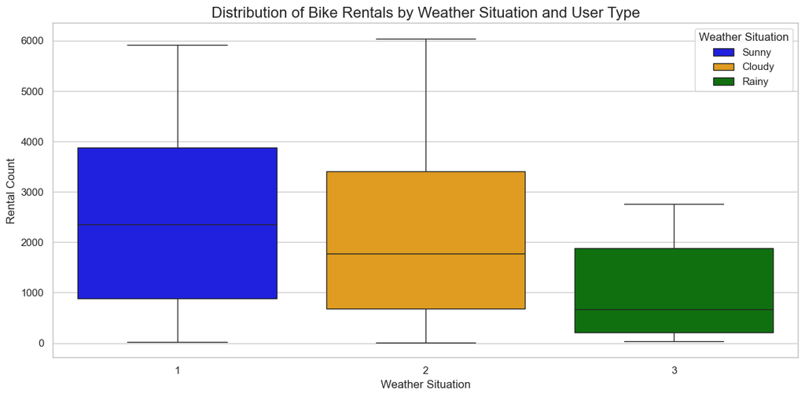

```python
data_2011 = data[data["yr"] == 0]

data_melted = data_2011[["weathersit", "casual", "registered", "cnt"]].melt(id_vars=["weathersit"],
                                                                        value_vars=["casual", "registered", "cnt"],
                                                                        var_name="user_type",
                                                                        value_name="rental_count")

plt.figure(figsize=(12, 6))

sns.boxplot(x="weathersit", y="rental_count", hue="weathersit", data=data_melted,
            palette={1: 'blue', 2: 'orange', 3: 'green'},
            showfliers=False)  # hide outliers for better visualization

plt.title("Distribution of Bike Rentals by Weather Situation and User Type", fontsize=16)
plt.xlabel("Weather Situation", fontsize=12)
plt.ylabel("Rental Count", fontsize=12)

plt.legend(title="Weather Situation", loc="upper right", labels=["Sunny", "Cloudy", "Rainy"])

plt.tight_layout()

plt.show()
```

### Question 10. (9 pts)

Create a visual comparison of the monthly trends in total bike rentals for each year presented. The figure should be arranged into two separate panels, one for each year: 2011 and 2012. On the x-axis, display the months, and on the y-axis, represent the average ('mean') count of bike rentals ('cnt') for each corresponding month. Additionally, incorporate error bars into the plot to indicate the standard error for the mean count of rentals for each month, providing insight into the variability of the data."

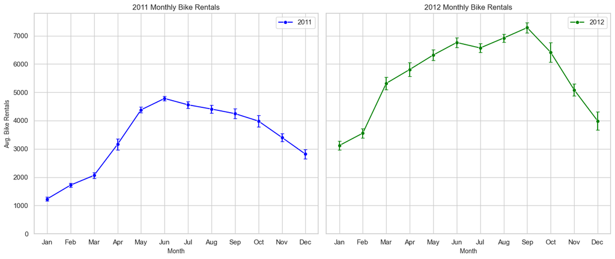

```python
data_2011 = data[data["yr"] == 0]
data_2012 = data[data["yr"] == 1]

monthly_avg_2011 = data_2011.groupby("mnth")["cnt"].agg(["mean", "sem"]).reset_index()
monthly_avg_2012 = data_2012.groupby("mnth")["cnt"].agg(["mean", "sem"]).reset_index()

fig, axes = plt.subplots(1, 2, figsize=(14, 6), sharey=True)

sns.lineplot(x = "mnth", y = "mean", data=monthly_avg_2011, ax=axes[0], marker = "o", color = "blue", label = "2011")
axes[0].errorbar(monthly_avg_2011["mnth"], monthly_avg_2011["mean"], yerr = monthly_avg_2011["sem"], fmt = "none",
                 color = "blue", capsize = 3)
axes[0].set_title("2011 Monthly Bike Rentals", fontsize = 12)
axes[0].set_xlabel("Month", fontsize=10)
axes[0].set_ylabel("Avg. Bike Rentals", fontsize = 10)
axes[0].set_xticks(range(1, 13))
axes[0].set_xticklabels(["Jan", "Feb", "Mar", "Apr", "May", "Jun", "Jul", "Aug", "Sep", "Oct", "Nov", "Dec"])
axes[0].set_ylim(0, monthly_avg_2011["mean"].max() + 500)

sns.lineplot(x = "mnth", y = "mean", data = monthly_avg_2012, ax=axes[1], marker="o", color="green", label="2012")
axes[1].errorbar(monthly_avg_2012["mnth"], monthly_avg_2012["mean"], yerr = monthly_avg_2012["sem"], fmt = "none",
                 color = "green", capsize = 3)
axes[1].set_title("2012 Monthly Bike Rentals", fontsize = 12)
axes[1].set_xlabel("Month", fontsize = 10)
axes[1].set_xticks(range(1, 13))
axes[1].set_xticklabels(["Jan", "Feb", "Mar", "Apr", "May", "Jun", "Jul", "Aug", "Sep", "Oct", "Nov", "Dec"])
axes[1].set_ylim(0, monthly_avg_2012["mean"].max() + 500)

plt.tight_layout()

plt.show()
```